# HW3

Ali Ozan Memetoğlu

1/9/2021

# Time Series Regression for Predicting Food and Nonalcoholic Beverage Price Index

## Introduction

The main objective of this study is to forecast the price index of food and nonalcoholic beverages in Turkey using the data from [Elektronik Veri Dağıtım Sistemi](https://evds2.tcmb.gov.tr/) with time series regression. Both relevant predictors and our target variable price index is taken from the same source. Monthly data is from 2012 January to 2020 December.

As relevant predictors:

- Consumer Confidence Index - CCI
- US Dollar Buying Exchange Rate - USD
- Personal Loan Interest Rate - IR

are used. According to investment.com. CCI is defined as: *“… a measure that examines the weighted average of prices of a basket of consumer goods and services, such as transportation, food, and medical care. It is calculated by taking price changes for each item in the predetermined basket of goods and averaging them. Changes in the CPI are used to assess price changes associated with the cost of living.”* which is thought to be a good predictor for price index, since it explains price changes well. There is no doubt that exchange rate will explain price and interest rate will also show somehow a relation with price index because in general, when interest rates are low, the economy grows and inflation increases.

## Manipulation

```r
library('data.table', quietly = TRUE)
library('ggplot2', quietly = TRUE)
library('dplyr')
library('lubridate', quietly = TRUE)
library('readxl')
library('zoo')
library ('fpp2')
library('corrplot')
df <- data.table(read_xlsx('/Users/aliozan.memetoglu/Downloads/EVDS (1).xlsx'))[,c('Date', 'TP DK USD A YTL','TP KTF10', 'TP FG J01', 'TP TG2 Y01')]
```

The file contains some extra parts. So a simple manipulator is introduced to convert date to a usable type. This manipulator is nothing but a cleaner for the file. It might be useful when new data is obtained for performance check, new data can be transformed just by changing the date part in the function.

```r
simple_manipulator <- function(someDT){

  someDT <- someDT %>% filter(grepl('-', Date))
  someDT[,Date := as.Date(as.yearmon(Date))]
  someDT <- someDT[Date >=  ymd(20120101) & Date <=  ymd(20201201) ]
  setnames(someDT, 'TP DK USD A YTL', 'USD')
  setnames(someDT, 'TP KTF10', 'IR')
  setnames(someDT, 'TP TG2 Y01', 'CCI')
  setnames(someDT, 'TP FG J01', 'CPI')
  return(someDT)
}
df <- simple_manipulator(df)
summary(df)
```

```
##       Date                USD                 IR                 CPI
##  Min.   :2012-01-01   Length:108         Length:108         Min.   :205.6
##  1st Qu.:2014-03-24   Class :character   Class :character   1st Qu.:260.1
##  Median :2016-06-16   Mode  :character   Mode  :character   Median :309.7
##  Mean   :2016-06-16                                         Mean   :347.6
##  3rd Qu.:2018-09-08                                         3rd Qu.:441.7
##  Max.   :2020-12-01                                         Max.   :608.1
##       CCI
##  Min.   :77.05
##  1st Qu.:82.95
##  Median :89.89
##  Mean   :88.46
##  3rd Qu.:92.54
##  Max.   :97.37
```

It is really not known that USD and IR predictors and in char type.

```r
df[,USD := as.double(USD)]
df[,IR := as.double(IR)]
summary(df)
```

```
##       Date                 USD              IR             CPI
##  Min.   :2012-01-01   Min.   :1.751   Min.   :10.61   Min.   :205.6
##  1st Qu.:2014-03-24   1st Qu.:2.125   1st Qu.:15.00   1st Qu.:260.1
##  Median :2016-06-16   Median :2.961   Median :17.19   Median :309.7
##  Mean   :2016-06-16   Mean   :3.640   Mean   :18.23   Mean   :347.6
##  3rd Qu.:2018-09-08   3rd Qu.:5.322   3rd Qu.:18.98   3rd Qu.:441.7
##  Max.   :2020-12-01   Max.   :8.003   Max.   :38.72   Max.   :608.1
##       CCI
##  Min.   :77.05
##  1st Qu.:82.95
##  Median :89.89
##  Mean   :88.46
##  3rd Qu.:92.54
##  Max.   :97.37
```

## Visualization

Both target, predictors and their correlations are observed before a ts object is created.

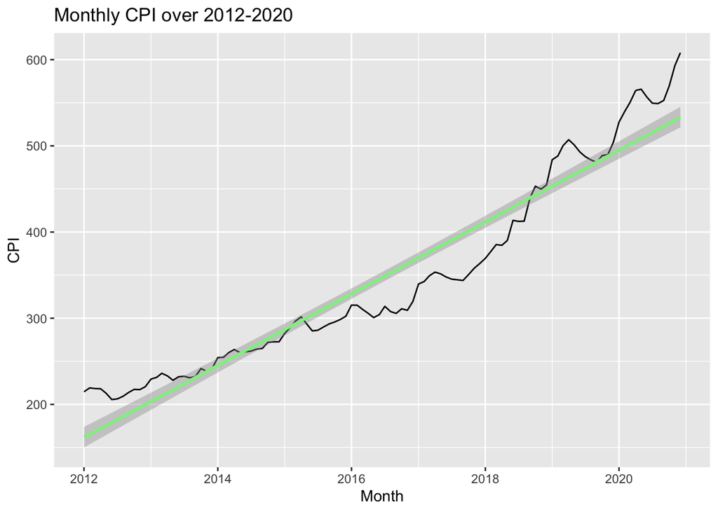

```r
ggplot(df, aes(x=Date, y=CPI)) + geom_line()+
  geom_smooth(method = "lm", color = 'lightgreen')+
  labs(title = "Monthly CPI over 2012-2020",
       x = "Month",
       y = "CPI")
```

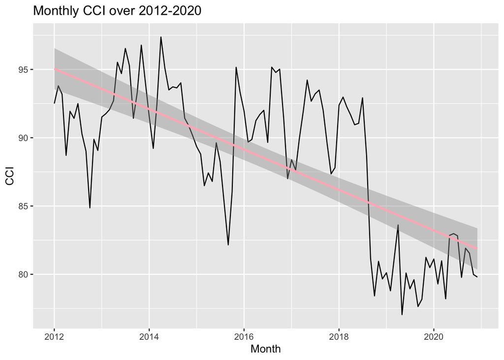

```r
ggplot(df, aes(x=Date, y=CCI)) + geom_line()+
  geom_smooth(method = "lm", color = 'lightpink')+
  labs(title = "Monthly CCI over 2012-2020",
       x = "Month",
       y = "CCI")
```

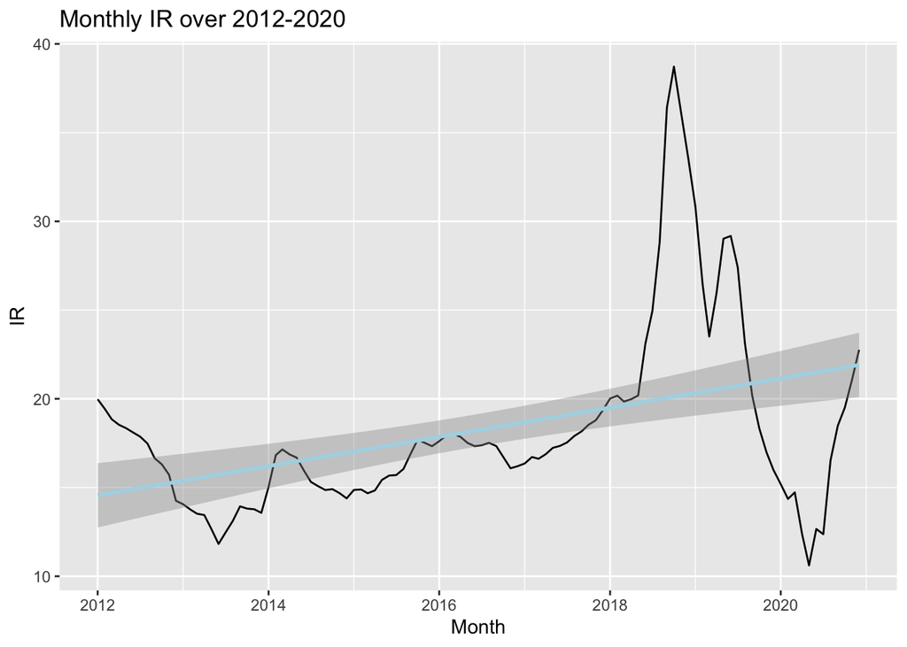

```r
ggplot(df, aes(x=Date, y=IR)) + geom_line()+
  geom_smooth(method = "lm", color = 'lightblue')+
  labs(title = "Monthly IR over 2012-2020",
       x = "Month",
       y = "IR")
```

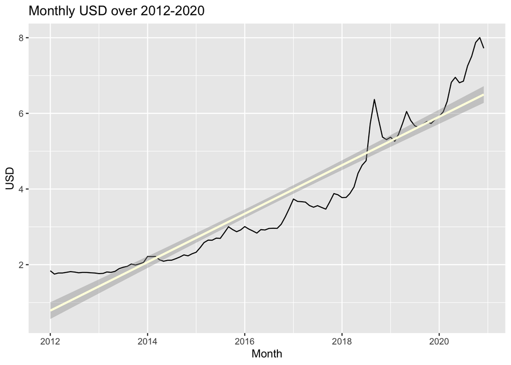

```r
ggplot(df, aes(x=Date, y=USD)) + geom_line()+
  geom_smooth(method = "lm", color = 'lightyellow')+
  labs(title = "Monthly USD over 2012-2020",
       x = "Month",
       y = "USD")
```

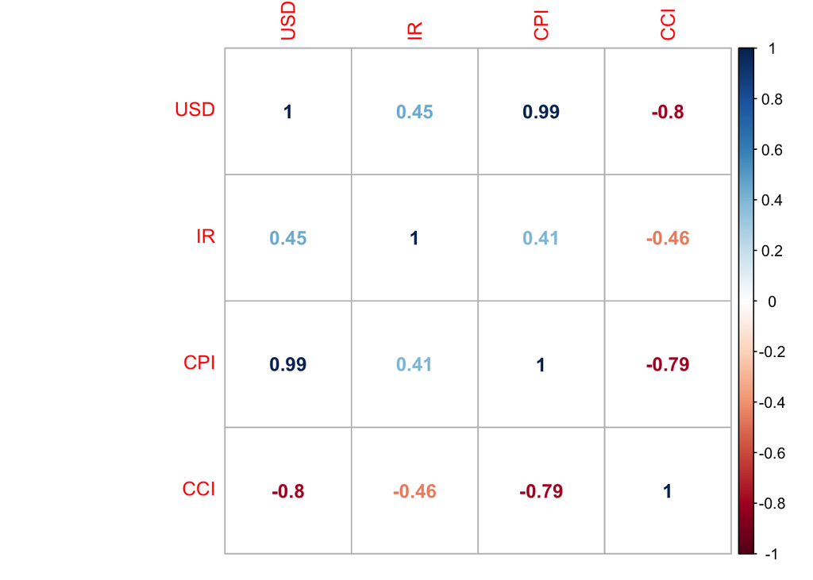

```r
corrplot(cor(df[,-1]), method= "number")
```

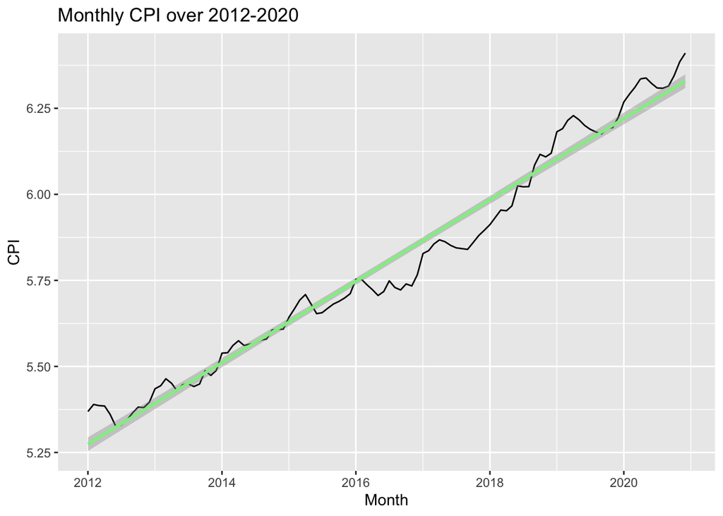

```r
ggplot(df, aes(x=Date, y=log(CPI))) + geom_line()+
  geom_smooth(method = "lm", color = 'lightgreen')+
  labs(title = "Monthly CPI over 2012-2020",
       x = "Month",
       y = "CPI")
```

## Analysis

Some models are created below.

```r
df_log <- df
df_log[,CPI := log(CPI)]
df_log[,USD := log(USD)]

fit1=lm( CPI ~ USD + CCI + IR, df_log)
summary(fit1)
```

```
##
## Call:
## lm(formula = CPI ~ USD + CCI + IR, data = df_log)
##
## Residuals:
##       Min        1Q    Median        3Q       Max
## -0.117688 -0.022256 -0.000345  0.032521  0.082227
##
## Coefficients:
##               Estimate Std. Error t value Pr(>|t|)
## (Intercept)  5.2268371  0.1157460  45.158  < 2e-16 ***
## USD          0.6675139  0.0137011  48.720  < 2e-16 ***
## CCI         -0.0016965  0.0011403  -1.488 0.139829
## IR          -0.0035208  0.0008872  -3.968 0.000133 ***
## ---
## Signif. codes:  0 '***' 0.001 '**' 0.01 '*' 0.05 '.' 0.1 ' ' 1
##
## Residual standard error: 0.04153 on 104 degrees of freedom
## Multiple R-squared:  0.9829, Adjusted R-squared:  0.9824
## F-statistic:  1992 on 3 and 104 DF,  p-value: < 2.2e-16
```

```r
fit2=lm( CPI ~ USD + CCI, df_log)
summary(fit2)
```

```
##
## Call:
## lm(formula = CPI ~ USD + CCI, data = df_log)
##
## Residuals:
##       Min        1Q    Median        3Q       Max
## -0.162537 -0.021484 -0.000757  0.036478  0.076522
##
## Coefficients:
##               Estimate Std. Error t value Pr(>|t|)
## (Intercept)  5.1133681  0.1197756   42.69   <2e-16 ***
## USD          0.6551496  0.0142482   45.98   <2e-16 ***
## CCI         -0.0009743  0.0012021   -0.81    0.419
## ---
## Signif. codes:  0 '***' 0.001 '**' 0.01 '*' 0.05 '.' 0.1 ' ' 1
##
## Residual standard error: 0.04435 on 105 degrees of freedom
## Multiple R-squared:  0.9803, Adjusted R-squared:  0.9799
## F-statistic:  2613 on 2 and 105 DF,  p-value: < 2.2e-16
```

```r
fit3=lm( CPI ~ USD + IR, df_log)
summary(fit3)
```

```
##
## Call:
## lm(formula = CPI ~ USD + IR, data = df_log)
##
## Residuals:
##       Min        1Q    Median        3Q       Max
## -0.128365 -0.021049 -0.002387  0.036235  0.090085
##
## Coefficients:
##               Estimate Std. Error t value Pr(>|t|)
## (Intercept)  5.0560997  0.0151764 333.155  < 2e-16 ***
## USD          0.6817534  0.0098604  69.140  < 2e-16 ***
## IR          -0.0033101  0.0008809  -3.758 0.000282 ***
## ---
## Signif. codes:  0 '***' 0.001 '**' 0.01 '*' 0.05 '.' 0.1 ' ' 1
##
## Residual standard error: 0.04177 on 105 degrees of freedom
## Multiple R-squared:  0.9825, Adjusted R-squared:  0.9822
## F-statistic:  2952 on 2 and 105 DF,  p-value: < 2.2e-16
```

```r
fit4=lm( CPI ~ USD, df_log)
summary(fit4)
```

```
##
## Call:
## lm(formula = CPI ~ USD, data = df_log)
##
## Residuals:
##       Min        1Q    Median        3Q       Max
## -0.161325 -0.023060 -0.001468  0.035266  0.080003
##
## Coefficients:
##             Estimate Std. Error t value Pr(>|t|)
## (Intercept) 5.016754   0.011645   430.8   <2e-16 ***
## USD         0.663977   0.009171    72.4   <2e-16 ***
## ---
## Signif. codes:  0 '***' 0.001 '**' 0.01 '*' 0.05 '.' 0.1 ' ' 1
##
## Residual standard error: 0.04428 on 106 degrees of freedom
## Multiple R-squared:  0.9802, Adjusted R-squared:   0.98
## F-statistic:  5242 on 1 and 106 DF,  p-value: < 2.2e-16
```

It can be seen that the negative effect of CCI was not really helpful probably due to collinearity. IR and USD model can be used but because most of the variation is explained by USD and later some additional seasonal effects will be introduced, it should be sufficient to use USD only. Now let’s introduce the trend variable.

```r
df_log[,trend:=1:.N]
fit5=lm( CPI ~ trend, df_log)
summary(fit5)
```

```
##
## Call:
## lm(formula = CPI ~ trend, data = df_log)
##
## Residuals:
##       Min        1Q    Median        3Q       Max
## -0.111849 -0.029445  0.001837  0.031237  0.105530
##
## Coefficients:
##              Estimate Std. Error t value Pr(>|t|)
## (Intercept) 5.2643825  0.0101763   517.3   <2e-16 ***
## trend       0.0098535  0.0001621    60.8   <2e-16 ***
## ---
## Signif. codes:  0 '***' 0.001 '**' 0.01 '*' 0.05 '.' 0.1 ' ' 1
##
## Residual standard error: 0.05251 on 106 degrees of freedom
## Multiple R-squared:  0.9721, Adjusted R-squared:  0.9719
## F-statistic:  3696 on 1 and 106 DF,  p-value: < 2.2e-16
```

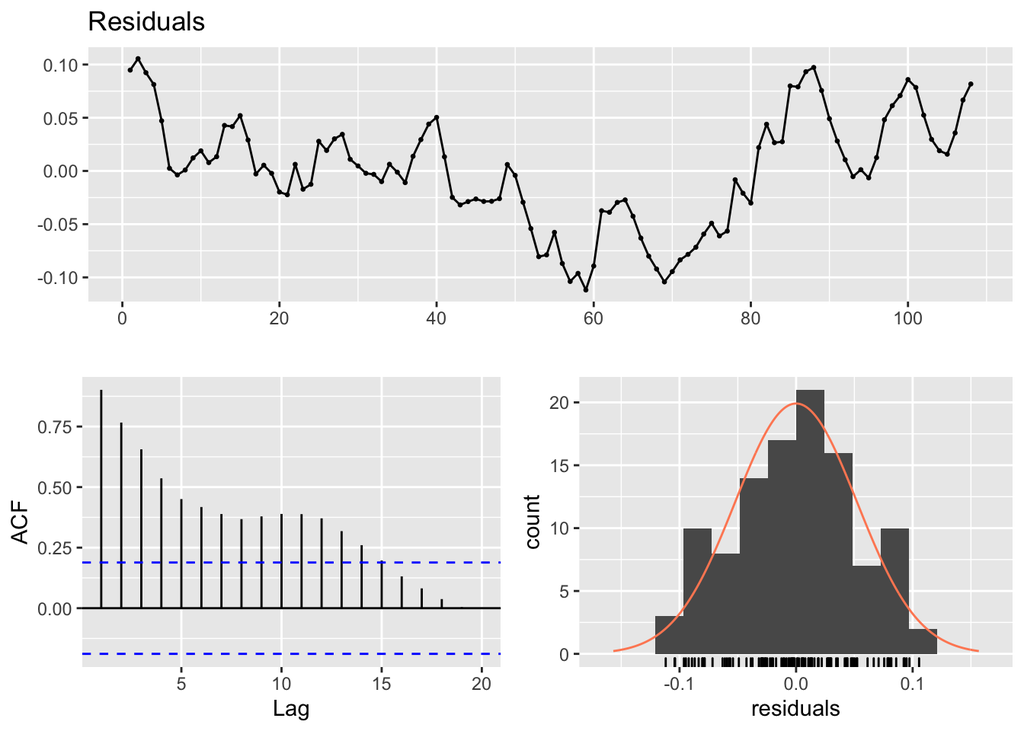

```
##
##  Breusch-Godfrey test for serial correlation of order up to 10
##
## data:  Residuals
## LM test = 94.192, df = 10, p-value = 7.868e-16
```

```r
checkresiduals(fit5)
```

From the summary stats, trend component explains variation in target very well. But when residuals of model are checked, both constant variation and zero mean assumptions are violated. Autocorrelation function of residuals also confirms this circumstance.

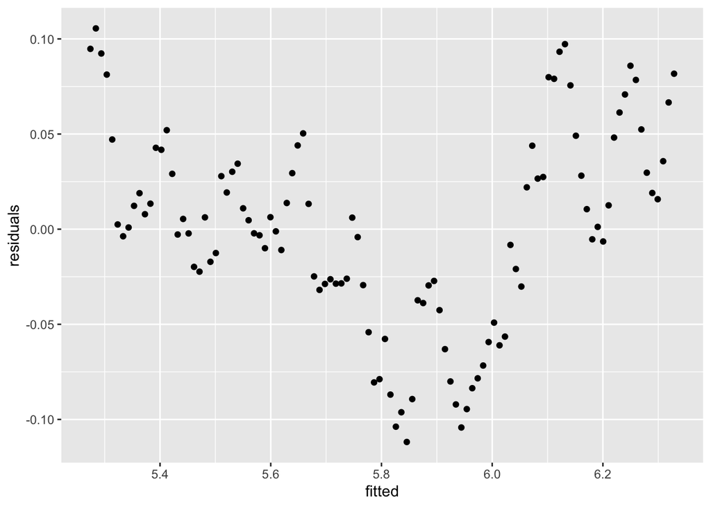

```r
fitted_res = data.table(residuals = residuals(fit5),fitted = fitted(fit5))
ggplot(fitted_res, aes(x = fitted, y = residuals)) +
  geom_point()
```

We can see the strong autocorrelation among residuals from fited residual plot, they are not scattered well. This can be fixed when the USD variable is used, it might also explain the seasonality effect.

```r
fit6=lm( CPI ~ trend + USD, df_log)
summary(fit6)
```

```
##
## Call:
## lm(formula = CPI ~ trend + USD, data = df_log)
##
## Residuals:
##       Min        1Q    Median        3Q       Max
## -0.109984 -0.026636 -0.000718  0.029954  0.078215
##
## Coefficients:
##              Estimate Std. Error t value Pr(>|t|)
## (Intercept) 5.1037371  0.0191415 266.632  < 2e-16 ***
## trend       0.0036948  0.0006839   5.402 4.13e-07 ***
## USD         0.4199739  0.0458979   9.150 4.93e-15 ***
## ---
## Signif. codes:  0 '***' 0.001 '**' 0.01 '*' 0.05 '.' 0.1 ' ' 1
##
## Residual standard error: 0.03935 on 105 degrees of freedom
## Multiple R-squared:  0.9845, Adjusted R-squared:  0.9842
## F-statistic:  3332 on 2 and 105 DF,  p-value: < 2.2e-16
```

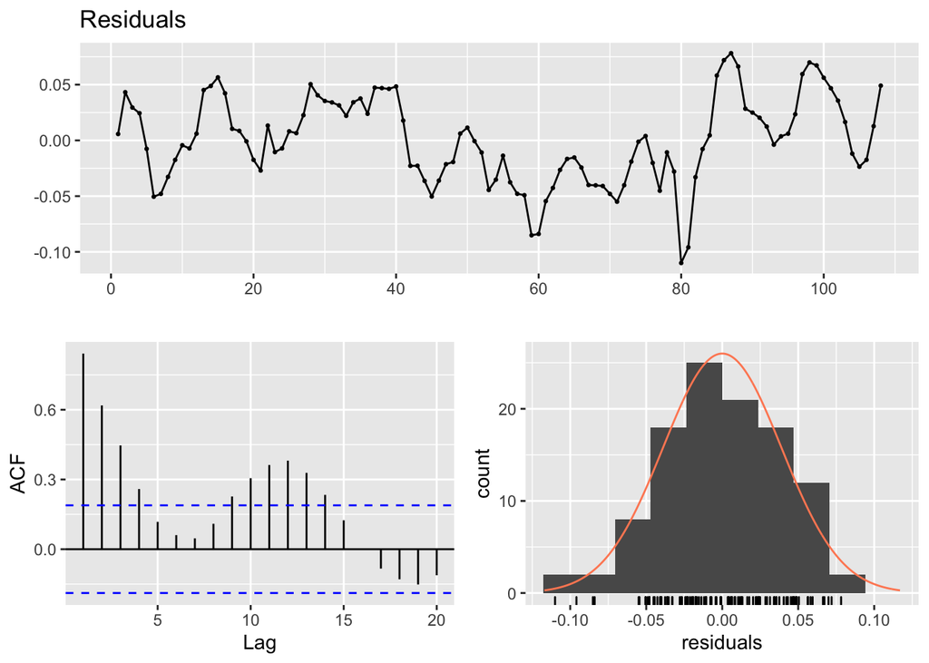

```
##
##  Breusch-Godfrey test for serial correlation of order up to 10
##
## data:  Residuals
## LM test = 87.241, df = 10, p-value = 1.884e-14
```

```r
checkresiduals(fit6)
```

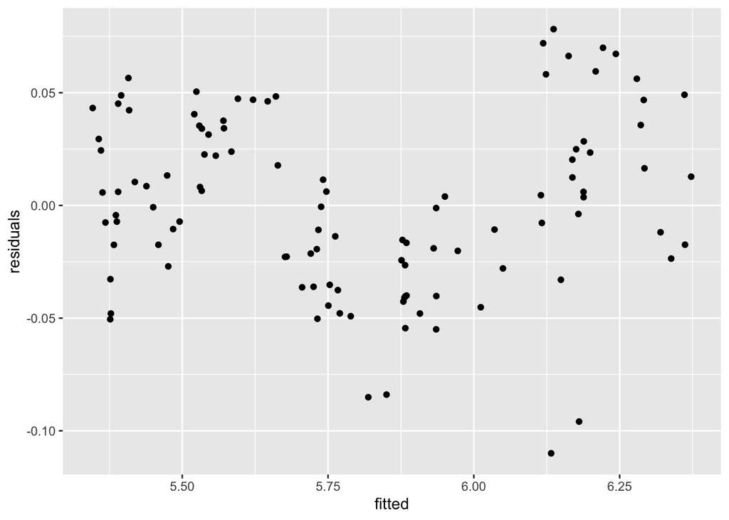

```r
fitted_res = data.table(residuals = residuals(fit6),fitted = fitted(fit6))
ggplot(fitted_res, aes(x = fitted, y = residuals)) +
  geom_point()
```

We still could not fix the problem at lag 1, 2 and 3 even though USD variable is introduced. And also we have a problem at lag 12, so USD could not account for the seasonality effect either.

```r
month <- seq(1,12,by=1)
df_log <- cbind(df_log, month)
df_log[,month:=as.factor(month)]

fit7=lm( CPI ~ trend + USD + month, df_log)
summary(fit7)
```

```
##
## Call:
## lm(formula = CPI ~ trend + USD + month, data = df_log)
##
## Residuals:
##       Min        1Q    Median        3Q       Max
## -0.085415 -0.020233  0.004878  0.025969  0.060212
##
## Coefficients:
##               Estimate Std. Error t value Pr(>|t|)
## (Intercept)  5.1162173  0.0208007 245.963  < 2e-16 ***
## trend        0.0036759  0.0006158   5.969  4.2e-08 ***
## USD          0.4252258  0.0413133  10.293  < 2e-16 ***
## month2       0.0109525  0.0166188   0.659  0.51148
## month3       0.0133284  0.0166120   0.802  0.42438
## month4       0.0091938  0.0166145   0.553  0.58133
## month5      -0.0141101  0.0166119  -0.849  0.39782
## month6      -0.0219488  0.0166279  -1.320  0.19004
## month7      -0.0267572  0.0166551  -1.607  0.11151
## month8      -0.0447075  0.0166238  -2.689  0.00847 **
## month9      -0.0495455  0.0166254  -2.980  0.00367 **
## month10     -0.0331107  0.0166319  -1.991  0.04941 *
## month11     -0.0324024  0.0166526  -1.946  0.05467 .
## month12     -0.0227876  0.0166717  -1.367  0.17493
## ---
## Signif. codes:  0 '***' 0.001 '**' 0.01 '*' 0.05 '.' 0.1 ' ' 1
##
## Residual standard error: 0.03522 on 94 degrees of freedom
## Multiple R-squared:  0.9889, Adjusted R-squared:  0.9873
## F-statistic:   643 on 13 and 94 DF,  p-value: < 2.2e-16
```

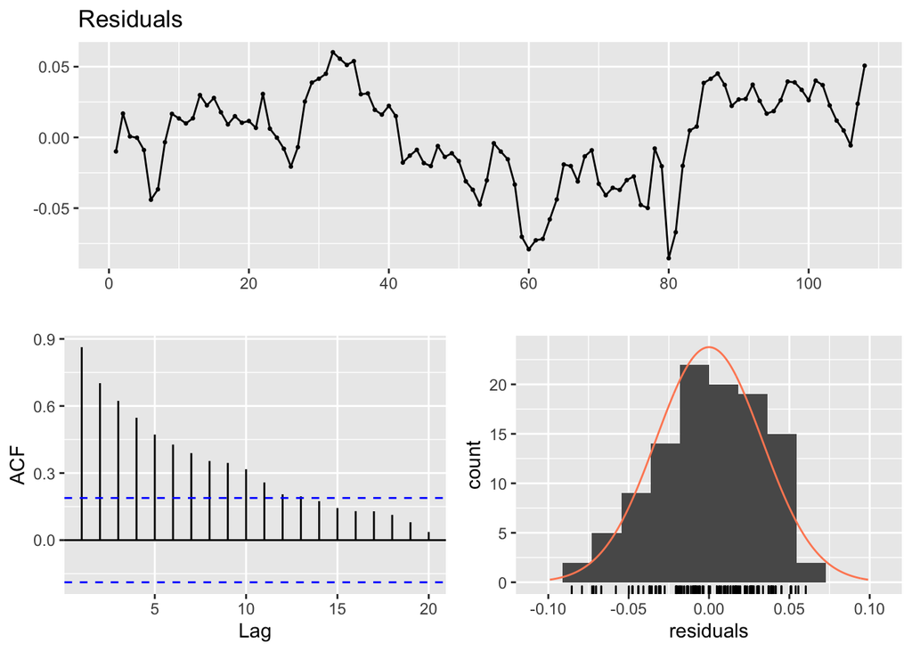

```
##
##  Breusch-Godfrey test for serial correlation of order up to 17
##
## data:  Residuals
## LM test = 87.271, df = 17, p-value = 1.907e-11
```

```r
checkresiduals(fit7)
```

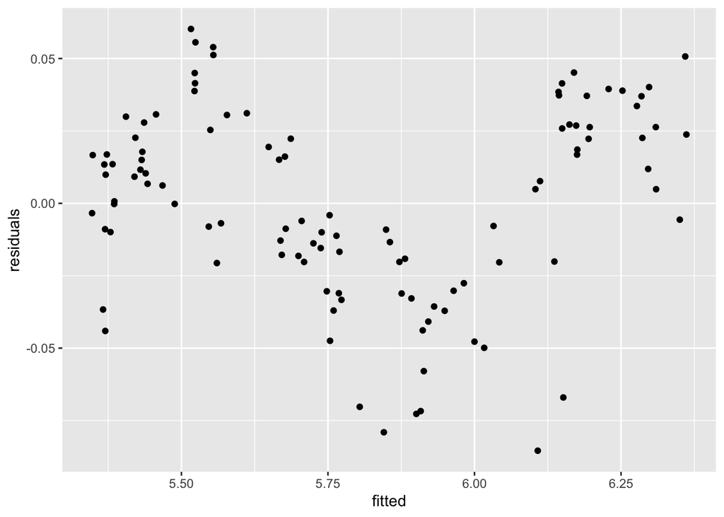

```r
fitted_res = data.table(residuals = residuals(fit7),fitted = fitted(fit7))
ggplot(fitted_res, aes(x = fitted, y = residuals)) +
  geom_point()
```

We still could not fix the problem at lag 1, 2 and 3! This is probably due to the price changes in seasons. We can add a season predictor. But in our case, seasonal effect is significant especially in summer period, probably since weather conditions are more favorable for nonalcoholic beverages and food. And we have an outlier at 79th data point that is clear without any percentage process used. That’s actually the month election happened! Instead of removing it, a new variable is prefered because it will be hard to model if it is removed. The mean of the two day and the day before election and after election is used for that day.

```r
season <- c(rep(1,2),rep(2,3), rep(3,3), rep(4,3), 1)
df_log <- cbind(df_log, season)
df_log[,season:=as.factor(season)]

df_log[79, 'CPI'] = mean(df_log[80, CPI],df_log[81, CPI],df_log[78, CPI], df_log[77, CPI] )

fit8=lm( CPI ~ trend + USD + month + season, df_log)
summary(fit8)
```

```
##
## Call:
## lm(formula = CPI ~ trend + USD + month + season, data = df_log)
##
## Residuals:
##       Min        1Q    Median        3Q       Max
## -0.085424 -0.020139  0.004871  0.025964  0.060218
##
## Coefficients: (3 not defined because of singularities)
##               Estimate Std. Error t value Pr(>|t|)
## (Intercept)  5.1161992  0.0207985 245.989  < 2e-16 ***
## trend        0.0036756  0.0006158   5.969  4.2e-08 ***
## USD          0.4252537  0.0413088  10.295  < 2e-16 ***
## month2       0.0109529  0.0166170   0.659  0.51142
## month3       0.0133285  0.0166102   0.802  0.42433
## month4       0.0091937  0.0166127   0.553  0.58129
## month5      -0.0141104  0.0166101  -0.850  0.39776
## month6      -0.0219490  0.0166261  -1.320  0.18999
## month7      -0.0266873  0.0166532  -1.603  0.11239
## month8      -0.0447083  0.0166220  -2.690  0.00846 **
## month9      -0.0495468  0.0166236  -2.981  0.00366 **
## month10     -0.0331119  0.0166301  -1.991  0.04937 *
## month11     -0.0324034  0.0166508  -1.946  0.05463 .
## month12     -0.0227886  0.0166699  -1.367  0.17487
## season2             NA         NA      NA       NA
## season3             NA         NA      NA       NA
## season4             NA         NA      NA       NA
## ---
## Signif. codes:  0 '***' 0.001 '**' 0.01 '*' 0.05 '.' 0.1 ' ' 1
##
## Residual standard error: 0.03521 on 94 degrees of freedom
## Multiple R-squared:  0.9889, Adjusted R-squared:  0.9873
## F-statistic: 643.2 on 13 and 94 DF,  p-value: < 2.2e-16
```

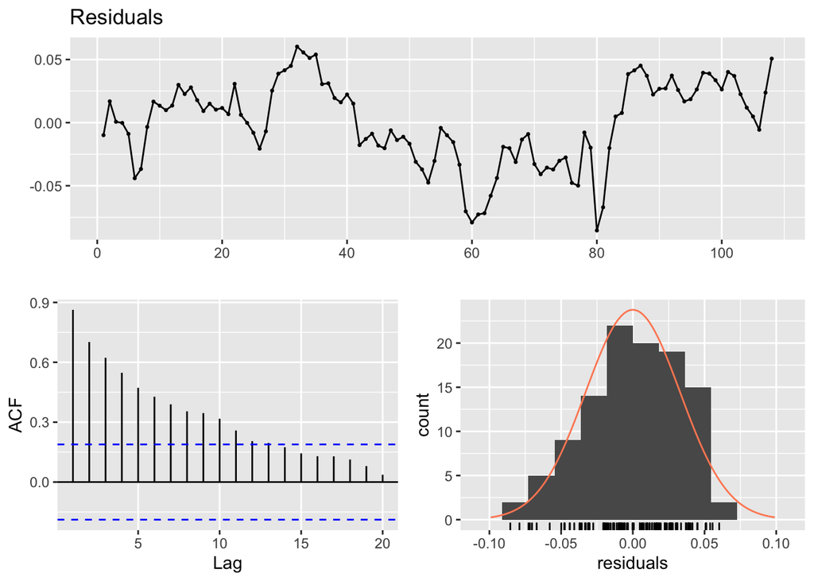

```
##
##  Breusch-Godfrey test for serial correlation of order up to 20
##
## data:  Residuals
## LM test = 87.445, df = 20, p-value = 2.066e-10
```

```r
checkresiduals(fit8)
```

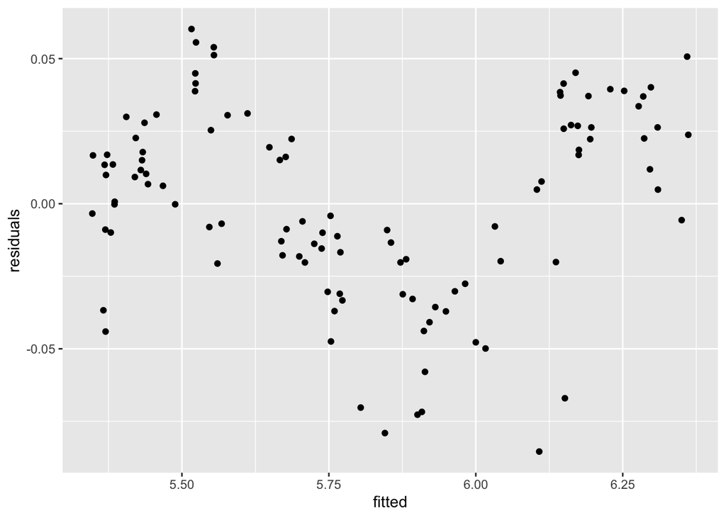

```r
fitted_res = data.table(residuals = residuals(fit8),fitted = fitted(fit8))
ggplot(fitted_res, aes(x = fitted, y = residuals)) +
  geom_point()
```

Because we still have this autoregression problem, we can append lag 1 residuals to the model or lag 1 values.

```r
df_log[,res_lag1 := lag(residuals(fit8),1)]
fit9=lm( CPI ~ trend + USD + month + season + res_lag1, df_log)


summary(fit9)
```

```
##
## Call:
## lm(formula = CPI ~ trend + USD + month + season + res_lag1, data = df_log)
##
## Residuals:
##       Min        1Q    Median        3Q       Max
## -0.070625 -0.008176 -0.001125  0.008455  0.036715
##
## Coefficients: (3 not defined because of singularities)
##               Estimate Std. Error t value Pr(>|t|)
## (Intercept)  5.1174508  0.0101680 503.288  < 2e-16 ***
## trend        0.0035085  0.0003127  11.219  < 2e-16 ***
## USD          0.4378303  0.0208492  21.000  < 2e-16 ***
## month2       0.0040944  0.0083675   0.489 0.625778
## month3       0.0063915  0.0083685   0.764 0.446965
## month4       0.0022460  0.0083669   0.268 0.788961
## month5      -0.0211294  0.0083691  -2.525 0.013293 *
## month6      -0.0288737  0.0083632  -3.452 0.000841 ***
## month7      -0.0335069  0.0083620  -4.007 0.000125 ***
## month8      -0.0517797  0.0083685  -6.187 1.67e-08 ***
## month9      -0.0568050  0.0083847  -6.775 1.16e-09 ***
## month10     -0.0402770  0.0083742  -4.810 5.88e-06 ***
## month11     -0.0394303  0.0083664  -4.713 8.64e-06 ***
## month12     -0.0297620  0.0083666  -3.557 0.000595 ***
## season2             NA         NA      NA       NA
## season3             NA         NA      NA       NA
## season4             NA         NA      NA       NA
## res_lag1     0.8866048  0.0510367  17.372  < 2e-16 ***
## ---
## Signif. codes:  0 '***' 0.001 '**' 0.01 '*' 0.05 '.' 0.1 ' ' 1
##
## Residual standard error: 0.0172 on 92 degrees of freedom
##   (1 observation deleted due to missingness)
## Multiple R-squared:  0.9974, Adjusted R-squared:  0.997
## F-statistic:  2480 on 14 and 92 DF,  p-value: < 2.2e-16
```

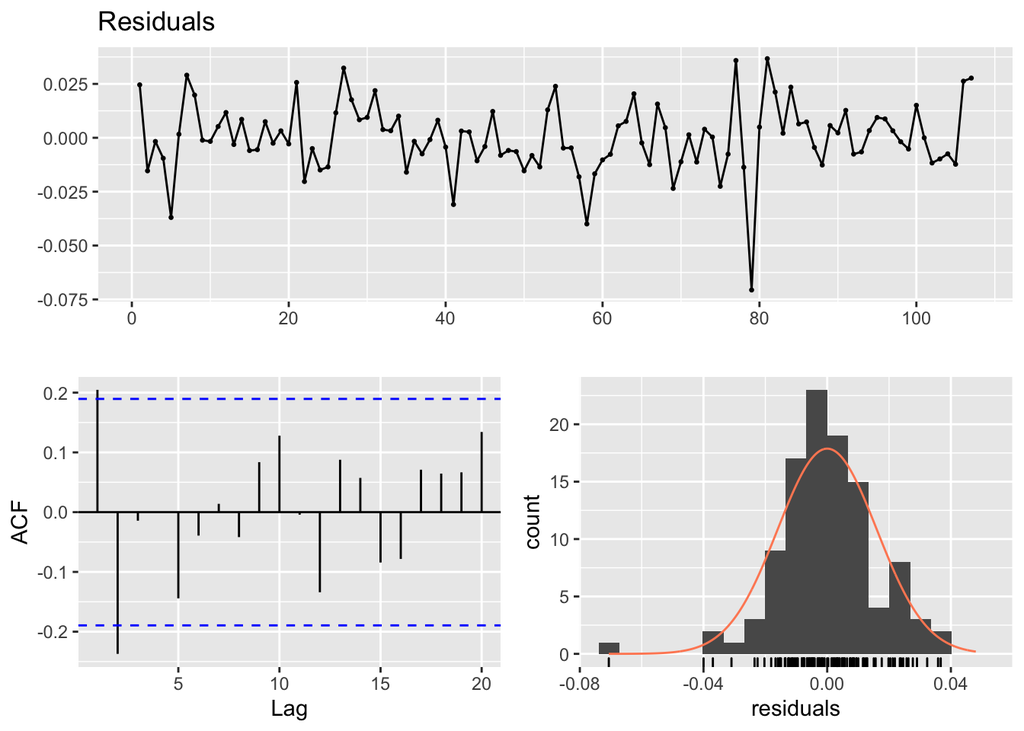

```
##
##  Breusch-Godfrey test for serial correlation of order up to 21
##
## data:  Residuals
## LM test = 29.608, df = 21, p-value = 0.1002
```

```r
checkresiduals(fit9)
```

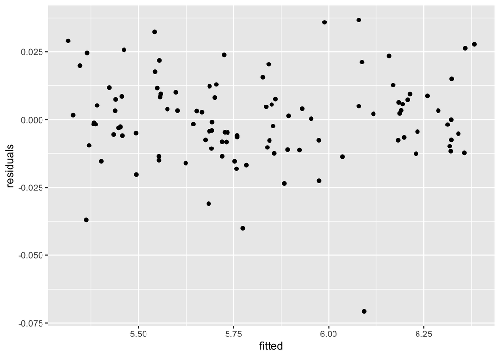

```r
fitted_res = data.table(residuals = residuals(fit9),fitted = fitted(fit9))
ggplot(fitted_res, aes(x = fitted, y = residuals)) +
  geom_point()
```

## Forecasting

In analysis part, last month is used but it is expected to forecast the last month value. So the same last modeling approach is going to be used to forecast the last month using the previous data. Before the forecasting, the predicted and actual values are visualized first.

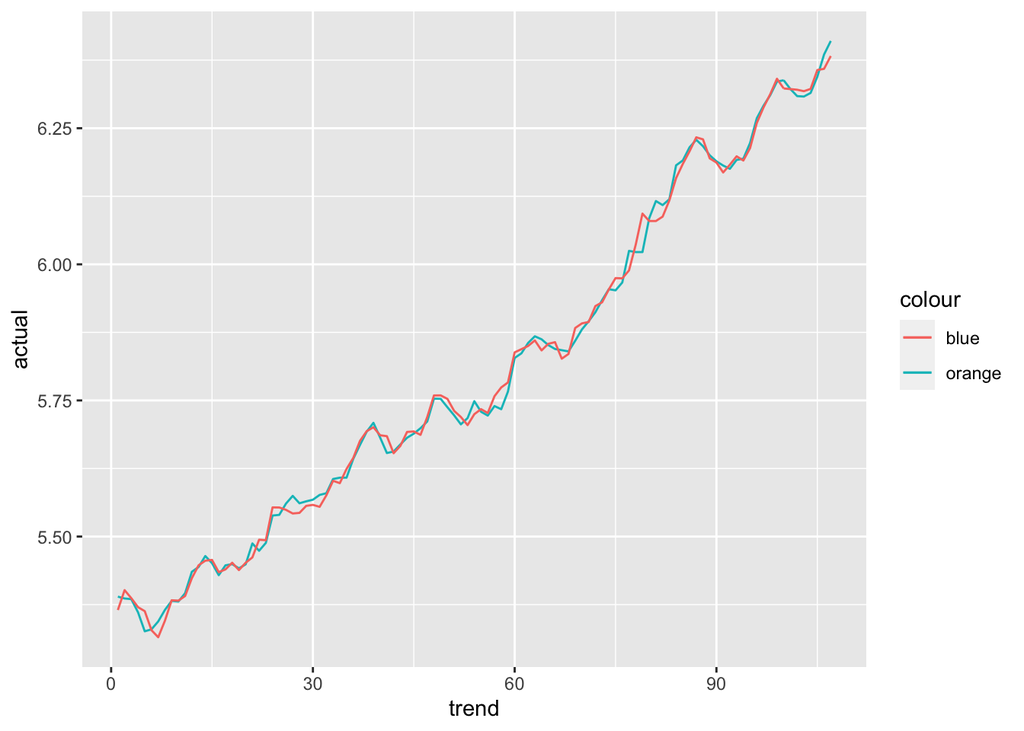

```r
visual_df = data.table(actual = df_log[2:108,CPI], predicted = fitted(fit9), trend = 1:107)
ggplot()+
  geom_line(data = visual_df, aes(x=trend, y=actual, color = 'orange'))+
  geom_line(data = visual_df, aes(x=trend, y=predicted, color = 'blue'))
```

The last actual value should be removed in order to perform the forecasting. Residual does not necessarily need to be removed because it is the residual of the day before.

```r
fit_final=lm( CPI ~ trend + USD + month + season + res_lag1, df_log[1:107])
dec_2020 <- df_log[108]
dec_2020[,'CPI'] = NA
predict(fit_final, dec_2020)
```

```
##        1
## 6.377695
```

```r
df_log[108]
```

```
##          Date      USD    IR      CPI     CCI trend month season   res_lag1
## 1: 2020-12-01 2.043952 22.76 6.410274 79.7966   108    12      1 0.02375907
```

# Conclusions and Remarks

The model could be improved with additional outlier analysis and some additional predictors related to price index could be used. What is more, forecasting period could be longer and some performance metrics such as Root Mean Squared Error or Mean Absolute Error could be used for a longer test period. There are many other variables effecting Consumer Price Index that could be observed and analyzed. For a better forecasting, events in Turkey that effect price indeces could have been examined more because many unstable events occur frequently in Turkey. To sum up, price index in Turkey can be modeled with a time series regression and USD exchange rate variable can be used. It is probably because most of our goods are imported from another country.